# Assignment 2 Report

Taylor Falk

11/17/2021

**Please read this brief introduction to R Markdown, and complete the second half of the document yourself.**

# R Markdown

R Markdown, `.Rmd` files, are a type of markdown files that can execute R code in an R environment. Markdown is an open source language used for easily creating documents such as web pages and PDFs. Markdown and R Markdown can be used to procedurally generate documents and reports, which have a wide number of use-cases across bioinformatics. Not only can you save time by creating code to automatically draft documents, you can also include detailed instructions and information alongside your code.

## knitr

`knitr` is simply the package R uses to convert the R Markdown into the appropriate output (HTML, PDF, or Word). While there is a deep level of customization available, most users can comfortably create beautiful documents with the default parameters. In order to compile your markdown, in RStudio you can select the `Knit` button below the open file button.

## Markdown Basics

The raw markdown, which you may or may not be looking at, is styled very basically. The largest titles start with one octothorpe `#`. The more `#`’s added, the smaller a title or header becomes.

# Biggest

## 2nd Biggest

### so on

#### and so forth

##### until you have

###### six octothorpes

then nothing happens.

Markdown can be styled a few different ways:  
`_italics_` -> *italics*  
`**bold**` -> **bold**  
`` `monospace` `` -> `monospace`, good for code

A good cheat sheet is the [Markdown Guide Cheat Sheet](https://www.markdownguide.org/cheat-sheet)

## R Code in Markdown

The really vital part of R Markdown is the inclusion of code snippets you can place into the document, which will run and print out to users. In this snippet I create a function that says hello and that text is printed inside the document.

```r
say_hi <- function() {
  return("Hello world.")
}
print(say_hi())
```

```
## [1] "Hello world."
```

The syntax of the **snippet* is simple, with three back ticks `` ``` `` indicating the start and end of the snippet, and a lower case `r` in curly braces `{}` to indicate what language is used: `{r}` indicates R, `{python}` indicates Python. R Markdown does not support every language, but there are use cases where one document running both R and Python code can prove extremely useful and concise. There is also a button in RStudio to insert a snippet, it is a small green `+C` in the top right of the editor.

```python
import datetime
print(f'Wishing you a wonderful hello from Python at {datetime.datetime.now()}')
```

```
## Wishing you a wonderful hello from Python at 2023-09-27 11:16:41.235922
```

I can also test my code in RStudio without having to knit the entire document by pressing the green “Play” arrow on the snippet I am interested in.

Finally, R Markdown scripts can `source()` other `.R` scripts and use them in their execution environment. This mean I can define a function in my `main.R` script and use it in my R Markdown snippets. Note that the converse is true, using `knitr::purl()`, and the code established in an R Markdown can be sourced, and *tested*, using an normal `.R` script.

Also note that the environment is carried from one snippet to another, so if I define a function or load a file in one snippet I can use those objects in later snippets.

```r
message <- 'The last example...for now.'
```

```r
print(paste(message, 'But there\'s always room for more.'))
```

```
## [1] "The last example...for now. But there's always room for more."
```

# Assignment

Using what you know from this document and the `main.R` script, use the functions from `main.R` to draw a boxplot of expression levels. Use this R Markdown document to describe your code as you are using it in this document, as done above. Take time to enhance your ggplot function from the `main.R` script with high quality visual aesthetics. Do not use default ggplot colors.

```r
# use source to load your functions from main.R into this document.
source("main.R")
library(tidyverse)
```

## Loading CSV with `load_expression()`

Importing data into R effectively is crucial. For our tasks, we prefer the tibble format, a modern representation of data frames in R. Load the data into a tibble as we have done in prior assignments.

```r
# Load the expression data
result_tib <- load_expression("data/example_intensity_data_subset.csv")
result_tib # Display the initial rows of the data
```

```
## # A tibble: 1,000 × 36
##    probe  GSM972389 GSM972390 GSM972396 GSM972401 GSM972409 GSM972412 GSM972413 GSM972422 GSM972429
##    <chr>      <dbl>     <dbl>     <dbl>     <dbl>     <dbl>     <dbl>     <dbl>     <dbl>     <dbl>
##  1 24241…      4.41      4.23      4.54      4.17      4.45      4.74      4.57      4.47      4.27
##  2 15564…      2.89      2.85      2.89      2.94      2.93      2.91      2.76      2.97      3.31
##  3 22064…      4.12      3.77      3.98      3.62      3.64      4.39      4.24      4.14      4.27
##  4 22042…      3.33      3.87      3.65      3.51      3.46      3.42      3.76      3.95      3.83
##  5 22827…      6.57      7.00      6.59      6.52      6.81      6.38      5.71      6.49      6.69
##  6 15560…      4.89      2.41      4.79      3.46      3.92      5.43      4.37      2.98      3.43
##  7 23615…      3.07      3.48      2.81      4.19      3.12      3.07      4.57      2.71      2.79
##  8 23718…      4.11      4.31      4.39      3.71      4.06      4.81      3.86      3.85      4.37
##  9 22968…      3.49      3.71      3.78      3.60      3.35      4.06      3.76      3.94      3.84
## 10 15701…      2.87      2.86      2.60      2.51      2.82      2.62      2.55      2.76      2.77
## # … with 990 more rows, and 26 more variables: GSM972433 <dbl>, GSM972438 <dbl>, GSM972440 <dbl>,
## #   GSM972443 <dbl>, GSM972444 <dbl>, GSM972446 <dbl>, GSM972453 <dbl>, GSM972457 <dbl>,
## #   GSM972459 <dbl>, GSM972463 <dbl>, GSM972467 <dbl>, GSM972472 <dbl>, GSM972473 <dbl>,
## #   GSM972475 <dbl>, GSM972476 <dbl>, GSM972477 <dbl>, GSM972479 <dbl>, GSM972480 <dbl>,
## #   GSM972487 <dbl>, GSM972488 <dbl>, GSM972489 <dbl>, GSM972496 <dbl>, GSM972502 <dbl>,
## #   GSM972510 <dbl>, GSM972512 <dbl>, GSM972521 <dbl>
```

## Filtering Rows with `filter_15()`

To effectively work with our vast dataset, it’s essential to filter out rows that don’t meet certain criteria. The `filter_15()` function does precisely this by retaining rows where at least 15% of the values surpass a log2(15) expression level—equivalent to approximately 3.9. Notably, the function returns only the probe IDs, providing a summarized view of the dataset that meets the criteria.

While one might initially consider using traditional loops for row-wise operations, such methods can be inefficient for large datasets. Leveraging functions from the Tidyverse, particularly from the `dplyr` package, offers a more efficient and readable approach. Functions like `filter()` and `mutate()` allow for swift data transformations, enhancing both clarity and performance.

```r
test_tib <- tibble(probe=c('1_s_at', '2_s_at', '3_s_at', '4_s_at'),
                   GSM1=c(1.0, 3.95, 4.05, 0.5),
                   GSM2=rep(1.6, 4),
                   GSM3=rep(2.5, 4),
                   GSM4=rep(3.99, 4),
                   GSM5=rep(3.0, 4),
                   GSM6=rep(1.0, 4),
                   GSM7=rep(0.5, 4))
filtered_probes <- c(filter_15(test_tib)$probe)
filtered_probes # Display the probe IDs that meet the criteria
```

```
## [1] "2_s_at" "3_s_at"
```

## Converting Affy IDs to HGNC Names: `affy_to_hgnc()`

Gene data often involves various identifiers, and converting between these can be crucial for data integration. The function `affy_to_hgnc()` serves this purpose by linking Affymetrix probe IDs to HGNC gene IDs using the `biomaRt` package. However, while `biomaRt` offers a direct connection to Ensembl, a comprehensive genomic database, its reliance on external APIs can lead to occasional connectivity issues. If errors arise during usage, they’re often due to these external connections rather than the code itself.

When implementing, remember: - Use the `ENSEMBL_MART_ENSEMBL` biomart and the `hsapiens_gene_ensembl` dataset. - Fetch the attributes `"affy_hg_u133_plus_2"` and `"hgnc_symbol"`. - Despite the function aiming to return a tibble, `biomaRt`’s `getBM()` only deals with data.frames. Utilize `dplyr::pull()` to transform a tibble to a character vector, and `dplyr::as_tibble()` for converting a data frame back to a tibble.

```r
# Converting a sample affy ID to HGNC
response <- affy_to_hgnc(tibble('1553551_s_at'))

# Checking for potential connectivity issues with Ensembl
if (inherits(response, "try-error")) {
    print("Could not connect to ENSEMBL.")
} else {
    head(response) # Display the first few mappings
}
```

```
## # A tibble: 4 × 2
##   affy_hg_u133_plus_2 hgnc_symbol
##   <chr>               <chr>
## 1 1553551_s_at        MT-ND1
## 2 1553551_s_at        MT-TI
## 3 1553551_s_at        MT-TM
## 4 1553551_s_at        MT-ND2
```

## Refining Data with reduce_data()

Our data preparation’s ultimate goal is to streamline the dataset, focusing on relevant genes to make visualization more efficient with ggplot from the tidyverse package. The reduce_data() function serves this purpose by integrating various inputs, such as:

The original expression data. Probe IDs linked to HGNC symbols. Lists of ‘good’ and ‘bad’ gene names. The function operates as follows:

Matches probe IDs with HGNC symbols using the base function match(). Introduces the new data at the appropriate position using tibble::add_column(). Segregates the genes into two categories, ‘good’ and ‘bad’, leveraging the which() function and the %in% operator. In the end, the output is a tibble streamlined to only the genes of interest, with a dedicated column indicating the gene’s category.

```r
# Sample data and gene lists
expression_data <- tibble(probe = c("1_s_at", "2_s_at", "3_s_at", "4_s_at"),
                          GSM1 = c(9.5, 7.6, 5.5, 1.3),
                          GSM2 = c(9.7, 7.2, 2.9, 2.0),
                          GSM3 = c(6.9, 4.3, 6.8, 4.5))
gene_names <- tibble(affy_hg_u133_plus_2 = c("1_s_at", "2_s_at", "3_s_at", "4_s_at"),
                     hgnc_symbol = c("A-REAL-GENE", "SONIC", "UTWPU", "p53"))
good_genes <- c("A-REAL-GENE")
bad_genes <- c("SONIC")

expression_data
```

```
## # A tibble: 4 × 4
##   probe   GSM1  GSM2  GSM3
##   <chr>  <dbl> <dbl> <dbl>
## 1 1_s_at   9.5   9.7   6.9
## 2 2_s_at   7.6   7.2   4.3
## 3 3_s_at   5.5   2.9   6.8
## 4 4_s_at   1.3   2     4.5
```

```r
# Applying the function
reduced_data <- reduce_data(expression_data, gene_names, good_genes, bad_genes)
reduced_data
```

```
## # A tibble: 2 × 6
##   probe  hgnc_symbol gene_set  GSM1  GSM2  GSM3
##   <chr>  <chr>       <chr>    <dbl> <dbl> <dbl>
## 1 1_s_at A-REAL-GENE good       9.5   9.7   6.9
## 2 2_s_at SONIC       bad        7.6   7.2   4.3
```

## Analysis of Gene Expressions

In our analysis, we aim to visualize the gene expressions categorized as ‘good’ and ‘bad’. Before visualizing, it’s crucial to ensure our data is structured correctly. For our visualization, we need the data in a long format, so we’ll start by converting our data to this format.

### Convert Data Format

```r
# Test on an artificial tibble matching the structure of the real one
test_wide <- tibble(probe = c("probe1", "probe2", "probe3", "probe4", "probe5", "probe6"),
                    hgnc_symbol = c("geneA", "geneB", "geneC", "geneD", "geneE", "geneF"),
                    gene_set = c("good", "bad", "bad", "good", "good", "bad"),
                    GSM1 = c(2.5, 3.3, 3.5, 1.8, 2.5, 3.3),
                    GSM2 = c(2.7, 3.7, 3.9, 2.2, 2.1, 3.9))

test_wide
```

```
## # A tibble: 6 × 5
##   probe  hgnc_symbol gene_set  GSM1  GSM2
##   <chr>  <chr>       <chr>    <dbl> <dbl>
## 1 probe1 geneA       good       2.5   2.7
## 2 probe2 geneB       bad        3.3   3.7
## 3 probe3 geneC       bad        3.5   3.9
## 4 probe4 geneD       good       1.8   2.2
## 5 probe5 geneE       good       2.5   2.1
## 6 probe6 geneF       bad        3.3   3.9
```

```r
long_format_data <- convert_to_long(test_wide)
long_format_data
```

```
## # A tibble: 12 × 5
##    probe  hgnc_symbol gene_set sample value
##    <chr>  <chr>       <chr>    <chr>  <dbl>
##  1 probe1 geneA       good     GSM1     2.5
##  2 probe1 geneA       good     GSM2     2.7
##  3 probe2 geneB       bad      GSM1     3.3
##  4 probe2 geneB       bad      GSM2     3.7
##  5 probe3 geneC       bad      GSM1     3.5
##  6 probe3 geneC       bad      GSM2     3.9
##  7 probe4 geneD       good     GSM1     1.8
##  8 probe4 geneD       good     GSM2     2.2
##  9 probe5 geneE       good     GSM1     2.5
## 10 probe5 geneE       good     GSM2     2.1
## 11 probe6 geneF       bad      GSM1     3.3
## 12 probe6 geneF       bad      GSM2     3.9
```

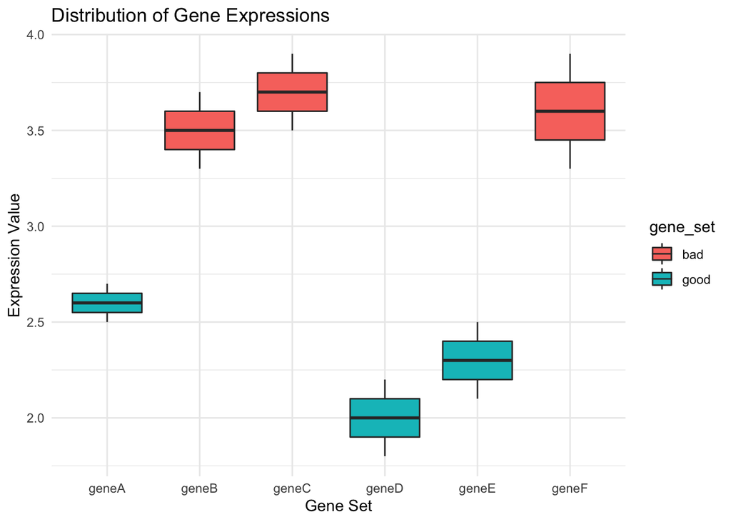

```r
library(ggplot2)

ggplot(long_format_data, aes(x = hgnc_symbol, y = value)) +
  geom_boxplot(aes(fill = gene_set)) +
  labs(title = "Distribution of Gene Expressions",
       x = "Gene Set",
       y = "Expression Value") +
  theme_minimal()
```